# Laboratorio 5

## Descripción de los datos

- *Blogs*: El tamaño de estos datos son de 899,288 palabras, proviene de un blog estadounidense. Además, el tipo de corpus es monolingüe, ya que el texto se encuentra escrito solamente en inglés; se encuentran emoticones, tales como corazones y caras escritas mediante los signos ortográficos. Aparecen muchas veces los signos de exclamación y se observa una escritura de narración para un público abierto.
- *News*: El tamaño de los datos es aproximadamente de 1,010,242, proviene de un noticiero en línea estadounidense. El tipo de corpus es monolingüe, ya que el texto se encuentra escrito solamente en inglés. No se observan emoticones pero sí links y caracteres especiales, así como los signos dólar.
- *Twitter*: El tamaño de estos datos son de aproximadamente 2,360,148 palabras, proviene de la red social twitter, donde el contenido es especificamente estadounidense. Además, el tipo de corpus es monolingüe, ya que el texto se encuentra escrito solamente en inglés; se encuentran emoticones, tales como corazones y caras escritas mediante los signos otográficos, signos de interrogación y exclamación, hashtags # y menciones @.

## Limpieza y preprocesamiento

El objetivo de este apartado es limpiar la muestra de 5% de los 3 textos usados: blogs, news y twitter. Los paquetes que se usaron para este laboratorio fueron los siguientes:

```r
#install.packages("wordcloud")
#install.packages("slam")
#install.packages("RColorBrewer")
#install.packages("devtools")
library("readr") #Lee los archivos
library("tm")  #Contiene tranformaciones para el text mining
library("SnowballC") #Stopwords
library("wordcloud")
library("RColorBrewer") #para las nubes de palabras
library(ggplot2) #para gráficos
library(dplyr) #manipualacion de texto
library(devtools) #Para instalar ngramas
#install_github("wrathematics/ngram")#descarga del paquete ngram
library(ngram) #para ngramas
library(data.table)
library(quanteda)
```

- *texto[[1]]$content*: Hace referencia al archivo de Blogs.
- *texto[[2]]$content*: Hace referencia al archivo de News.
- *texto[[3]]$content*: Hace referencia al archivo de Twitter.

Se realiza una vista previa para cada archivo, con el fin de saber la cantidad de palabras que hay en cada muestra y verificar que la extracción de datos aleatorios se haya realizado correctamente para las muestras del 5%. Se observa que para **blogs**, quedaron 44,964 palabras; para **news**, quedaron 50,521 palabras; para **twitter**, quedaron 118,007 palabras.

```r
#inspect(blog)
#inspect(news)
#inspect(twitter)
```

### Letras mayúsculas a minúsculas

Se cambian las letras a minúsculas, así se logra obtener un texto más homogéneo.

```r
blog <- tm_map(blog, tolower)
```

```
transformation drops documents
```

```r
news <- tm_map(news,tolower)
```

```
transformation drops documents
```

```r
twitter <- tm_map(twitter, tolower)
```

```
transformation drops documents
```

### Eliminación de caracteres especiales, emoticones y url

Se eliminan los emoticones, las url, usuario de twitter y hashtags que aparecen en los textos. Se usó la función de gsub() para facilitar y ahorrar el tema de los espacios. A continuación se explican a detalle de la definición dentro de gsub():

- *[^01-7F]*: En este caso, el ^ significa que el gsub() va a borrar todo excepto lo que sigue a continuación: 01-7F, es decir, borrará todo excepto los caracteres del código ASCII. Basicamente esta función ayuda a eliminar emoticones.
- *http[[:alnum:][:punct:]]*: Busca las palabras que empiecen con http y elimina los caracteres que siguen después de él, incluyendo signos de puntuación.
- *@[[:alnum:][:punct:]]$*: Busca las palabras que empiecen con una arroba (una mención, en el caso de twitter) y elimina los caracteres que siguen después de ello, incluyendo signos de puntuación.
- *#[^[:space:]]*: Busca los hashtags (palabras que empiecen con el #) y las elimina. En este caso no es necesario colocar los signos de puntuación.

### Eliminación de stopwords

Se elminan todos los artículos y preposiciones con la función de *stopwords()*. Esta función permite eliminar aquellas palabras que están juntadas por apóstrofes en el idioma inglés.

```r
blog <- tm_map(blog, removeWords, stopwords("english"))
```

```
transformation drops documents
```

```r
news <- tm_map(news, removeWords, stopwords("english"))
```

```
transformation drops documents
```

```r
twitter <- tm_map(twitter, removeWords, stopwords("english"))
```

```
transformation drops documents
```

### Eliminación de signos de puntuación

```r
blog <- tm_map(blog, removePunctuation)
```

```
transformation drops documents
```

```r
news <- tm_map(news, removePunctuation)
```

```
transformation drops documents
```

```r
twitter <- tm_map(twitter, removePunctuation)
```

```
transformation drops documents
```

### Eliminación de conjugaciones de palabras

También se decidió eliminar las conjugaciones de las palabras (pasado, futuro, gerundios, etc) y se dejó la palabra escrita en el presente. Se le aplica a todo el corpus de las muestras con la ayuda de la función tm_map().

```r
#blog <- tm_map(blog, stemDocument)

#news <- tm_map(news, stemDocument)

#twitter <- tm_map(twitter, stemDocument)
```

Cuando realizamos este procedimiento, nos dimos cuenta que al momento de sacar los n-gramas, las palabras perdían un poco de léxico y se creaban faltas ortográficas (e.g., la palabra *happy* se convertía en *happi*). Por eso mismo, decidimos no aplicar esta transformación.

### Eliminación de números

Por último, se eliminan los números, ya que consideramos que interferirán en las predicciones; es de suma importancia lograr predecir las primeras tres palabras y consideramos que es más sencillo si eliminamos los números.

```r
blog <- tm_map(blog, removeNumbers)
```

```
transformation drops documents
```

```r
news <- tm_map(news, removeNumbers)
```

```
transformation drops documents
```

```r
twitter <- tm_map(twitter, removeNumbers)
```

```
transformation drops documents
```

## Análisis Exploratorio

Obteniendo las palabras más frecuentes, se tomó la decisión de encontrar las que se encuentren por lo menos más de 1000 veces. Por otro lado, utilizamos la función removeSparseTerms() para deshacernos de las palabras más infrecuentes. Esto se hace con el motivo de poder disminuir el peso de MB para cada matriz.

```r
dtmBlog <- DocumentTermMatrix(blog)

#Se convierten en un term document matrix
#blogM <-  TermDocumentMatrix(blog)

findFreqTerms(dtmBlog, lowfreq=1000)
```

```
 [1] "now"       "book"      "know"      "love"      "new"       "week"      "may"       "something" "time"
[10] "said"      "just"      "made"      "can"       "first"     "last"      "really"    "days"      "even"
[19] "every"     "god"       "going"     "home"      "much"      "next"      "one"       "since"     "thought"
[28] "put"       "best"      "get"       "great"     "way"       "always"    "lot"       "though"    "used"
[37] "work"      "around"    "see"       "day"       "end"       "feel"      "like"      "need"      "place"
[46] "right"     "take"      "things"    "good"      "think"     "away"      "come"      "dont"      "give"
[55] "say"       "two"       "find"      "many"      "another"   "make"      "never"     "thing"     "years"
[64] "family"    "also"      "well"      "people"    "sure"      "still"     "life"      "long"      "little"
[73] "back"      "got"       "today"     "want"      "look"      "part"      "read"      "year"      "old"
[82] "world"     "use"       "better"
```

```r
dtmTwitter <- DocumentTermMatrix(twitter)

#Se convierten en un term document matrix

#twitterM <- TermDocumentMatrix(twitter)


findFreqTerms(dtmTwitter, lowfreq=1000)
```

```
 [1] "great"   "just"    "now"     "get"     "going"   "need"    "good"    "can"     "today"   "really"  "time"
[12] "much"    "night"   "love"    "know"    "make"    "come"    "back"    "lol"     "well"    "got"     "like"
[23] "happy"   "thank"   "tonight" "new"     "people"  "way"     "day"     "last"    "work"    "see"     "think"
[34] "right"   "thanks"  "want"    "hope"    "follow"  "life"    "one"     "best"    "still"
```

```r
dtmNews <- DocumentTermMatrix(news)

#Se convierten en un term document matrix

#newsM <- TermDocumentMatrix(news)


findFreqTerms(dtmNews, lowfreq=1000)
```

```
 [1] "says"    "best"    "new"     "way"     "city"    "said"    "many"    "years"   "can"     "good"    "home"
[12] "think"   "back"    "game"    "get"     "school"  "three"   "first"   "team"    "got"     "million" "made"
[23] "people"  "well"    "another" "day"     "one"     "two"     "going"   "make"    "much"    "percent" "state"
[34] "just"    "say"     "year"    "see"     "season"  "still"   "high"    "last"    "next"    "work"    "take"
[45] "even"    "time"    "want"    "also"    "four"    "police"  "right"   "know"    "now"     "like"    "county"
[56] "may"     "week"    "public"  "since"
```

### Nube de palabras

#### Archivo Blogs

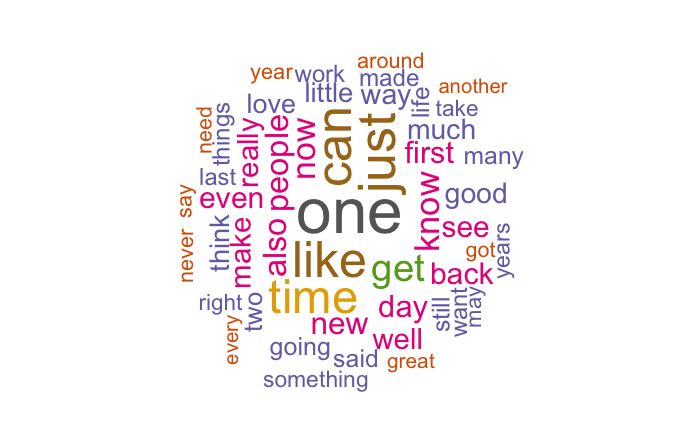

#### Archivo Twitter

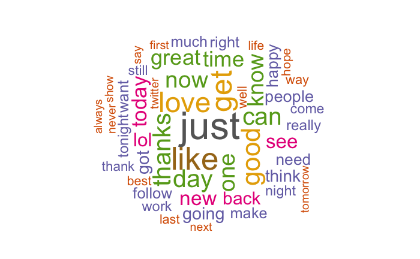

#### Archivo News

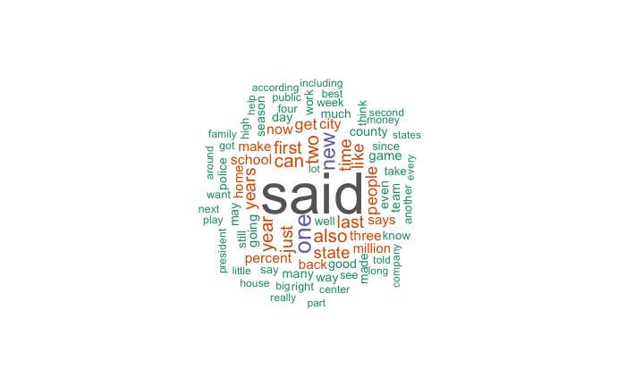

### Histogramas

|  | word | freq |
| --- | --- | --- |
| likud | likud | 2 |
| party | party | 416 |
| winner | winner | 150 |
| academic | academic | 47 |
| across | across | 456 |
| america | america | 214 |

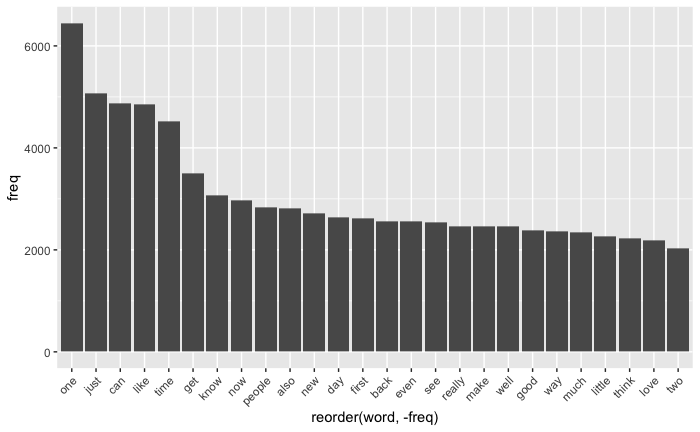

#### Archivo Twitter

|  | word | freq |
| --- | --- | --- |
| connections | connections | 12 |
| emotion | emotion | 11 |
| great | great | 2267 |
| just | just | 4508 |
| movie | movie | 324 |
| believe | believe | 325 |

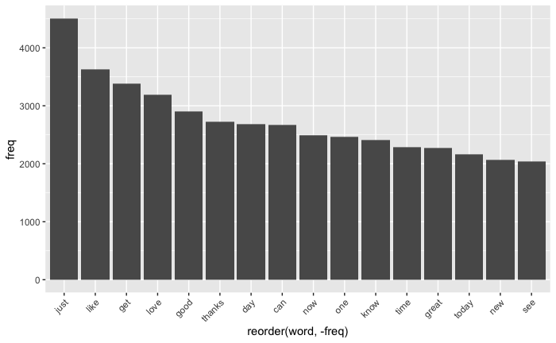

#### Archivo News

|  | word | freq |
| --- | --- | --- |
| anyone | anyone | 254 |
| attack | attack | 165 |
| bit | bit | 297 |
| borders | borders | 31 |
| break | break | 203 |
| come | come | 856 |

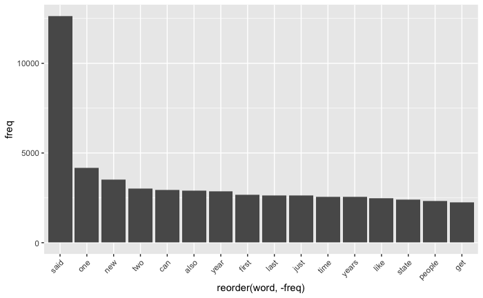

## N-gramas

Se comienza creando un string para cada corpus, para luego poder ser aplicado el n-grama

Se crean los bigramas para cada corpus.

### Bigramas del archivo Blogs

| ngrams | freq | prop |
| --- | --- | --- |
| right now | 256 | 2.686389e-04 |
| years ago | 251 | 2.633921e-04 |
| new york | 246 | 2.581452e-04 |
| even though | 242 | 2.539477e-04 |
| first time | 228 | 2.392565e-04 |
| can see | 205 | 2.151210e-04 |
| feel like | 197 | 2.067260e-04 |
| last year | 191 | 2.004298e-04 |
| make sure | 184 | 1.930842e-04 |
| one day | 177 | 1.857386e-04 |

[output cut: 990 more lines]

### Bigramas del archivo Twitter

| ngrams | freq | prop |
| --- | --- | --- |
| right now | 519 | 1.050382e-03 |
| last night | 355 | 7.184693e-04 |
| looking forward | 251 | 5.079882e-04 |
| just got | 226 | 4.573917e-04 |
| happy birthday | 224 | 4.533440e-04 |
| good morning | 223 | 4.513202e-04 |
| looks like | 215 | 4.351293e-04 |
| feel like | 189 | 3.825090e-04 |
| thanks follow | 185 | 3.744136e-04 |
| let know | 171 | 3.460796e-04 |

[output cut: 990 more lines]

### Bigramas del archivo News

| ngrams | freq | prop |
| --- | --- | --- |
| last year | 644 | 6.702490e-04 |
| new york | 561 | 5.838659e-04 |
| high school | 471 | 4.901976e-04 |
| st louis | 457 | 4.756270e-04 |
| new jersey | 379 | 3.944478e-04 |
| years ago | 349 | 3.632250e-04 |
| last week | 337 | 3.507359e-04 |
| los angeles | 266 | 2.768420e-04 |
| two years | 258 | 2.685159e-04 |
| united states | 250 | 2.601898e-04 |

[output cut: 990 more lines]

A continuación se encontrarán los trigramas

### Trigramas del archivo Blogs

| ngrams | freq | prop |
| --- | --- | --- |
| new york city | 39 | 4.092550e-05 |
| new york times | 34 | 3.567864e-05 |
| couple weeks ago | 26 | 2.728367e-05 |
| incorporated item c | 22 | 2.308618e-05 |
| new york ny | 21 | 2.203681e-05 |
| every single day | 19 | 1.993807e-05 |
| long time ago | 19 | 1.993807e-05 |
| nuclear power plant | 18 | 1.888869e-05 |
| two years ago | 18 | 1.888869e-05 |
| fukushima daiichi nuclear | 18 | 1.888869e-05 |

[output cut: 990 more lines]

### Trigramas del archivo Twitter

| ngrams | freq | prop |
| --- | --- | --- |
| happy mothers day | 107 | 2.165532e-04 |
| let us know | 70 | 1.416703e-04 |
| happy new year | 57 | 1.153601e-04 |
| cinco de mayo | 29 | 5.869198e-05 |
| looking forward seeing | 25 | 5.059653e-05 |
| happy happy happy | 22 | 4.452495e-05 |
| done done done | 21 | 4.250109e-05 |
| just got back | 21 | 4.250109e-05 |
| call call call | 20 | 4.047723e-05 |
| just got home | 20 | 4.047723e-05 |

[output cut: 990 more lines]

### Trigramas del archivo News

| ngrams | freq | prop |
| --- | --- | --- |
| president barack obama | 80 | 8.326083e-05 |
| two years ago | 68 | 7.077170e-05 |
| new york city | 56 | 5.828258e-05 |
| st louis county | 47 | 4.891574e-05 |
| gov chris christie | 46 | 4.787498e-05 |
| three years ago | 38 | 3.954889e-05 |
| world war ii | 31 | 3.226357e-05 |
| cents per share | 30 | 3.122281e-05 |
| new york times | 29 | 3.018205e-05 |
| past two years | 28 | 2.914129e-05 |

[output cut: 990 more lines]

## Probabilidades de palabras y Kneser-Kney Smoothing

Para realizar el algoritmo de Kneser-Kney Smoothing, proseguimos a unir los 3 datasets limpios a uno solo. Luego, lo convertimos a un corpus. Esto se hizo con el fin que al momento de estar aplicando el algoritmo de predicción con los ngramas, se tuviera una mayor base de datos de donde sacar información para las predicciones. Luego, se convirtió a un corpus y se le aplicó el preprocesamiento que se usó anteriormente, con la única diferencia que esta vez se trabaja con tokens. Se crean los ngramas usando tokens y luego se transforman a una matriz de documentación de texto. Se crea una tabla cuyas columnas tenga las palabras individuales de los uni/bi/tri-gramas.

```r
sumsU <- colSums(uni)
```

[output not shown]

### Probabilidad de los bigramas usando KNP

Con este algoritmo, proseguimos a calcular la probabilidad de las palabras de cada ngrama realizado. En este caso, calculamos la probabilidad de los bigramas creados por el programa. Como primer caso, se calcula el nú,ero de bigramas que hay en el corpus, luego se saca la probabilidad de una palabra dada y que esta pueda ser la segunda palabra del bigrama.

```r
valordes <- 0.75

# ***************************************
# Probablidad de encontrar un bigrama
# ***************************************

# Se calcula el número de bigramas que hay en total
numOfBiGrams <- nrow(bigram.pal[by = .(word_1, word_2)])
```

[output not shown]

### Probabilidad de los uni usando KNP

En este apartado, se buscan las primeras 50 palabras más frecuentadas en el unigrama. Ya que un unigrama se conforma de una sola palabra, no hay necesidad de comparar palabras sino que este es el resultado por default si ninguna de las palabras en los ngramas mayores no hacen match.

## Algoritmo de predicción

En esta parte, creamos una función que devuelva la siguiente palabra más probable de aparecer según una palabra previa. Esto se hizo con el fin de que a partir de cierto texto que ingrese el usuario, el programa devuelve la siguiente palabra con su probabilidad de aparecer en el texto. En el caso de los trigramas, se toman las dos palabras previas y se comparan con la tercera palabra del trigrama, si este hace match, entonces la predicción de la palabra es la tercera palabra del trigrama. En caso no diera match, se reducen las palabras analizar y se toma solamente la última palabra ingresada por el usuario y se compara en el bigrama; si la palabra hace match con la segunda palabra del bigrama, la función devuelve esta misma. Si no hace match, entonces el resultado que devuelve la función es la palabra con más frecuencia del unigrama.

### Modelo a prueba

Ahora, se juntan las tres funciones ya creadas anteriormente y se compactan en una sola. En este caso, es necesario que el usario ingrese en la consola el nombre de la función de la siguiente manera:
$$getWords("\text{texto que el usuario desee ingresar}")$$

La función devuele las 3 siguientes predicciones con su respectivo valor de probabilidad.

```r
# Lo que debería ir en la consola:
getWords("we shall go to")
```

```
[1] "Predicción 1: see. Probabilidad: 0.198070998400096"
[1] "Predicción 2: say. Probabilidad: 0.166698715233825"
[1] "Predicción 3: well. Probabilidad: 0.126219427615715"
```